# Stan models

Gilles Lijnzaad

2026-02-16

# 1 The data

## 1.1 Running the simulation

For the full simulation code, see run_sim().

```r
rm(list = ls())
main_dir <- "~/research/climate-RL/"
sim_dir <- paste0(main_dir, "R_simulation/")
sim <- new.env()
source(paste0(sim_dir, "sim.R"), local = sim)  # access functions using sim$fun()

params <- list(
  n_part = 20,
  n_trials = 30,
  LR = 0.3,
  inv_temp = 1.2,
  initQF = 3,
  initQU = 7,
  mu_R = c(5, 5), # F and U
  sigma_R = 3
)

sim_dat <- sim$run_sim(params, save_to_JSON = FALSE)

cat(paste0("PARAMETER SETTINGS:"), capture.output(dplyr::glimpse(params)), sep = "\n")
```

```
## PARAMETER SETTINGS:
## List of 8
##  $ n_part  : num 20
##  $ n_trials: num 30
##  $ LR      : num 0.3
##  $ inv_temp: num 1.2
##  $ initQF  : num 3
##  $ initQU  : num 7
##  $ mu_R    : num [1:2] 5 5
##  $ sigma_R : num 3
```

```r
cat(paste0("SIMULATED DATA:"), capture.output(dplyr::glimpse(sim_dat)), sep = "\n")
```

```
## SIMULATED DATA:
## Rows: 600
## Columns: 8
## $ participant <int> 1, 1, 1, 1, 1, 1, 1, 1, 1, 1, 1, 1, 1, 1, 1, 1, 1, 1, 1, 1…
## $ trial       <int> 1, 2, 3, 4, 5, 6, 7, 8, 9, 10, 11, 12, 13, 14, 15, 16, 17,…
## $ Q_F         <dbl> 3.0000, 3.0000, 3.0000, 3.9000, 3.9000, 3.9300, 3.9300, 3.…
## $ Q_U         <dbl> 7.000000, 6.100000, 4.870000, 4.870000, 4.309000, 4.309000…
## $ P_F         <dbl> 0.008162571, 0.023660578, 0.095868271, 0.237941224, 0.3797…
## $ choice      <dbl> 2, 2, 1, 2, 1, 2, 2, 2, 2, 2, 2, 2, 2, 2, 2, 2, 2, 2, 2, 2…
## $ R           <dbl> 4, 2, 6, 3, 4, 7, 7, 6, 4, 8, 6, 8, 1, 8, 5, 7, 8, 4, 4, 5…
## $ pred_err    <dbl> -3.00000000, -4.10000000, 3.00000000, -1.87000000, 0.10000…
```

## 1.2 Inspecting the data

Just so I know what to expect of our model, I include plots of the Q values and choices over time.

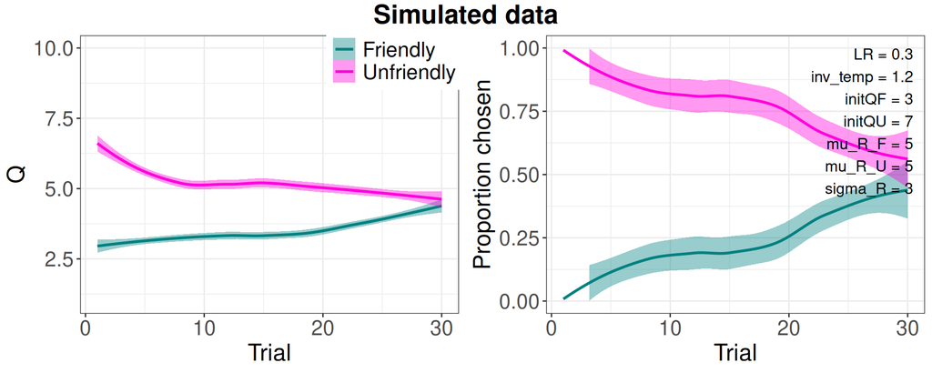

```r
library(grid)
library(gridExtra)

plot <- new.env()
source(paste0(main_dir, "plot_utils.R"), local = plot)  # access functions using plot$fun()

grid.arrange(plot$Q(sim_dat), plot$choice(sim_dat), nrow = 1,
             top = textGrob("Simulated data", gp = gpar(fontsize = 20, font = 2)))
plot$param_annotation(params, extra_vertical_spacing = TRUE)
```

# 2 Explaining the model

I show the Stan model code bit by bit to explain what is happening. The full code can be found in climate-RL.stan.

## 2.1 `data` block

The data we supply to the model consist of:

1. the number of participants: `n_part`;
2. the number of trials per participant: `n_trials`;
3. an array of choices that a participant made: `choice[n_part, n_trials]`;
4. an array of ratings that a participant gave: `R[n_part, n_trials]`. These are analogous to the array `outcomes[n_trials]` in the `2arm_bandit_example` (see [Stan code](https://github.com/gilleslijnzaad/climate-RL-modeling/blob/main/stan_models/2arm_bandit_example/2arm_bandit_example.stan) for this example).

```r
mod_code <- readLines("climate-RL.stan")
start <- grep("data \\{", mod_code)[1]
end <- grep("transformed data \\{", mod_code) - 2
cat(mod_code[start:end], sep = "\n")
```

```
data {
  int<lower=1> n_part;
  int<lower=1> n_trials;
  array[n_part, n_trials] int<lower=1, upper=2> choice;
  array[n_part, n_trials] int<lower=1, upper=10> R;
}
```

## 2.2 `transformed data` block

Currently unused.

```r
start <- grep("transformed data \\{", mod_code)
end <- grep("parameters \\{", mod_code)[1] - 2
cat(mod_code[start:end], sep = "\n")
```

## 2.3 `parameters` block

In the current model, we have four free parameters:

1. learning rate;
2. inverse temperature;
3. initial Q value for the climate-friendly option;
4. initial Q value for the climate-unfriendly option.

When I make the model hierarchical, these parameters will be group-level means and standard deviations.

```r
start <- grep("parameters \\{", mod_code)[1]
end <- grep("transformed parameters \\{", mod_code) - 2
cat(mod_code[start:end], sep = "\n")
```

```
parameters {
  real<lower=1, upper=10> initQF;
  real<lower=1, upper=10> initQU;
  real<lower=0, upper=1> LR;
  real<lower=0, upper=5> inv_temp;
}
```

## 2.4 `transformed parameters` block

Currently unused. Will be used to define individual parameter values based on the group mean.

```r
start <- grep("transformed parameters \\{", mod_code)
end <- grep("model \\{", mod_code) - 2
cat(mod_code[start:end], sep = "\n")
```

## 2.5 `model` block

### 2.5.1 The priors

```r
start <- grep("model \\{", mod_code)
end <- grep("participant loop", mod_code)[1] - 2
cat(mod_code[start:end], sep = "\n")
```

```
model {
  // this is where priors would go. leaving them empty leads to uninformative priors
```

### 2.5.2 Participant loop

For every participant I initialize an array for holding the Q values. I also create a temporary vector `Q_t` that holds the two Q values (F, U) for the *current* trial, because otherwise the `categorical_logit` wouldn’t work, somehow. This works for now, and maybe in the future I will find a more elegant solution.

```r
start <- grep("participant loop", mod_code) + 1
end <- grep("trial loop", mod_code) - 2
cat(mod_code[start:end], sep = "\n")
```

```
  for (j in 1:n_part) {
    array[n_trials, 2] real Q;
    Q[1, 1] = initQF;
    Q[1, 2] = initQU;
    vector[2] Q_t;

    real pred_err;
```

### 2.5.3 Trial loop

```r
start <- grep("trial loop", mod_code) + 1
end <- grep("generated quantities", mod_code) - 2
cat(mod_code[start:end], sep = "\n")
```

```
    for (t in 1:n_trials) {
      Q_t = to_vector(Q[t]);

      // sample choice (1 is F, 2 is U) via softmax
      choice[j, t] ~ categorical_logit(inv_temp * Q_t);

      // prediction error
      pred_err = R[j, t] - Q[t, choice[j, t]];

      // update value (learn)
      if (t < n_trials) {    // no updating in the very last trial
        if (choice[j, t] == 1) {
          Q[t+1, 1] = Q[t, 1] + LR * pred_err;
          Q[t+1, 2] = Q[t, 2];
        } else {
          Q[t+1, 1] = Q[t, 1];
          Q[t+1, 2] = Q[t, 2] + LR * pred_err;
        }
      }
    }
  }
}
```

## 2.6 `generated quantities` block

Currently unused. Will be used in the future to generate posterior predictions.

```r
start <- grep("generated quantities", mod_code)
end <- length(mod_code)
cat(mod_code[start:end], sep = "\n")
```

# 3 Fitting the model

## 3.1 Run it

To save running time, I only refit the model if the simulated data have changed (i.e., if I changed parameter settings). To this end, I compare the previously saved `sim_data.json` to the current `sim_dat`. After this comparison, I can save the new `sim_data` and refit the model if necessary.

```r
data_file <- paste0(sim_dir, "sim_dat.json")
dat_changed <- sim$did_sim_dat_change(data_file, sim_dat)
sim$save_sim_dat(params, sim_dat)
model_changed <- FALSE

library(cmdstanr)
options(mc.cores = parallel::detectCores())
if (dat_changed | model_changed) {
  m <- cmdstan_model("climate-RL.stan")
  it <- 1000
  fit <- m$sample(
    data = data_file,
    iter_sampling = it,
    chains = 1,
    thin = 1,
    iter_warmup = it / 2,
    refresh = it / 5,
    seed = 1234
  )
  fit$save_object(file = "climate-RL_fit.rds")
} else {
  fit <- readRDS(file = "climate-RL_fit.rds")
}
```

## 3.2 Inspect results

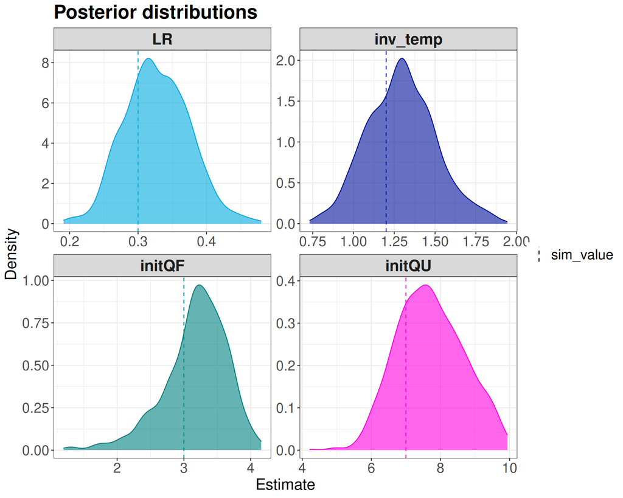

```r
plot$posterior_density(fit, c("LR", "inv_temp", "initQF", "initQU"), params)
```

```r
cred_int <- function(posterior_dist) {
  return(as.numeric(quantile(posterior_dist, c(0.025, 0.975))))
}

print_posterior_table <- function(fit, to_show, param_settings) {
  table_data <- data.frame()

  for (param in to_show) {
    sim_value <- param_settings[[param]]
    dat <- data.frame(
      parameter = param,
      sim_value = sim_value,
      median_CI = sprintf("%.2f [%.2f, %.2f]",
                          median(fit$draws(param)),
                          cred_int(fit$draws(param))[1],
                          cred_int(fit$draws(param))[2])
    )
    table_data <- rbind(table_data, dat)
  }
  colnames <- c("Parameter", "Simulated value",
                "Median [95% credibility interval]")
  knitr::kable(table_data,
               col.names = colnames,
               align = "lll",
               caption = "Posteriors for all free parameters") %>%
  kableExtra::kable_styling(full_width = FALSE, position = "left")
}

print_posterior_table(fit, c("LR", "inv_temp", "initQF", "initQU"), params)
```

Posteriors for all free parameters

| Parameter | Simulated value | Median [95% credibility interval] |
| --- | --- | --- |
| LR | 0.3 | 0.32 [0.24, 0.42] |
| inv_temp | 1.2 | 1.30 [0.91, 1.73] |
| initQF | 3.0 | 3.24 [2.06, 3.94] |
| initQU | 7.0 | 7.66 [6.01, 9.56] |

# 4 Some next steps

1. Hierarchically estimate parameter values for participants;
2. Implement confirmation bias;
3. Create a `generated quantities` block to see what Q values, choices and ratings the model predicts;
4. “Cosmetic” improvement: remove the temporary `Q_t` vector;